# Kiểm tra lần 2 - KDL 1

Nguyễn Thành Duy

2026-06-04

# Bài tập Nhóm 1: Tiền xử lý dữ liệu và Khám phá phân phối

## 1. Khởi tạo và Làm sạch dữ liệu

Sinh ngẫu nhiên 5000 quan sát từ phân phối chuẩn $N(60, 15^2)$, sau đó giả lập lỗi hệ thống bằng cách chèn 150 giá trị `NA` và 50 giá trị âm vào vector.

```r
raw_time <- rnorm(5000, mean = 60, sd = 15)

na_indices <- sample(1:5000, 150)
raw_time[na_indices] <- NA

non_na_indices <- which(!is.na(raw_time))
neg_indices <- sample(non_na_indices, 50)
raw_time[neg_indices] <- runif(50, -30, -1)
```

Loại bỏ toàn bộ giá trị `NA` và giá trị âm, lưu kết quả vào `final_data`:

```r
cleaned_time <- raw_time[!is.na(raw_time) & raw_time >= 0]
final_data <- data.frame(Time = cleaned_time)
n_cleaned <- nrow(final_data)
cat("Kich thuoc mau sau khi lam sach:", n_cleaned)
```

```
## Kich thuoc mau sau khi lam sach: 4800
```

Kích thước mẫu giảm từ 5000 xuống còn $5000 - 150 - 50 = 4800$ quan sát hợp lệ.

## 2. Khám phá phân phối

Tính trung bình mẫu $\bar{X}$ và độ lệch chuẩn mẫu $S$, sau đó vẽ Histogram tần suất tương đối kèm đường mật độ chuẩn lý thuyết:

```r
mean_time <- mean(final_data$Time)
sd_time <- sd(final_data$Time)

cat("Mean:", round(mean_time, 4), "| SD:", round(sd_time, 4))
```

```
## Mean: 60.0199 | SD: 14.8881
```

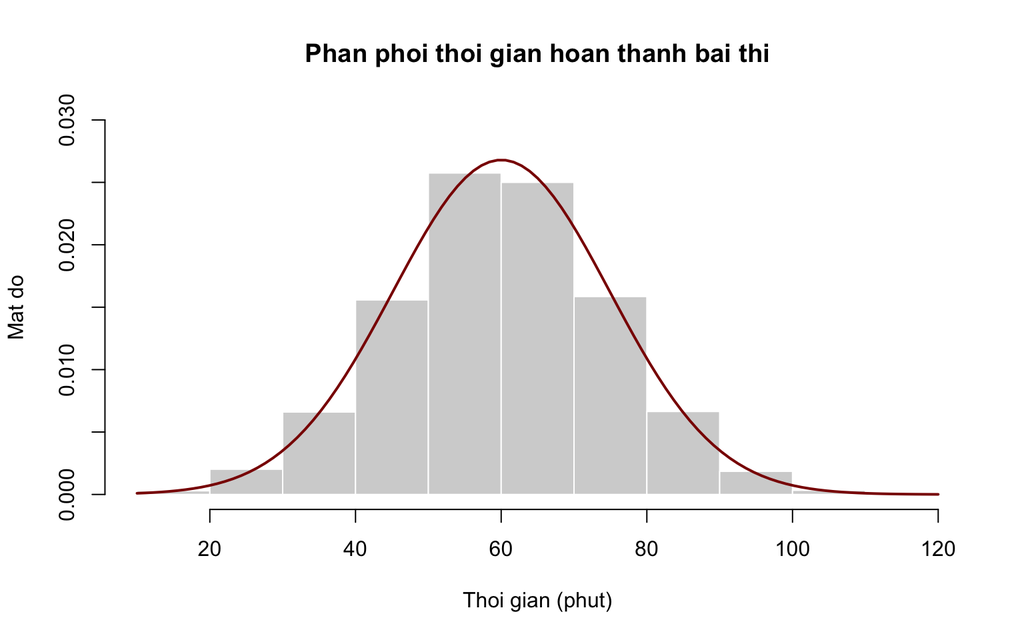

```r
hist(final_data$Time,
  freq = FALSE,
  main = "Phan phoi thoi gian hoan thanh bai thi",
  xlab = "Thoi gian (phut)",
  ylab = "Mat do",
  col = "lightgray",
  border = "white",
  ylim = c(0, 0.03)
)

curve(dnorm(x, mean = mean_time, sd = sd_time),
  add = TRUE,
  col = "darkred",
  lwd = 2
)
```

Đường mật độ chuẩn $N(\bar{X}, S^2)$ khớp rất tốt với dạng phân phối thực nghiệm của mẫu dữ liệu.

## 3. Ứng dụng hàm xác suất

Xác suất một sinh viên hoàn thành bài thi sớm hơn 45 phút:

```r
prob_early <- pnorm(45, mean = mean_time, sd = sd_time)
cat("P(Time < 45) =", round(prob_early, 4))
```

```
## P(Time < 45) = 0.1565
```

## 4. Hàm phân vị

Mốc thời gian tối đa để nằm trong Top 5% sinh viên nộp bài nhanh nhất (đuôi trái của phân phối):

```r
reward_threshold <- qnorm(0.05, mean = mean_time, sd = sd_time)
cat("Moc thoi gian nhan thuong (Top 5%):", round(reward_threshold, 2), "phut")
```

```
## Moc thoi gian nhan thuong (Top 5%): 35.53 phut
```

# Bài tập Nhóm 2: Lập trình Mô phỏng và Hệ quả CLT

## 1. Viết hàm tổng quát

Hàm `simulate_clt_exp` lặp lại `num_rep` lần việc rút mẫu kích thước $n$ từ phân phối Mũ $Exp(\lambda)$ và tính trung bình mẫu:

```r
simulate_clt_exp <- function(n, lambda, num_rep = 5000) {
  means <- numeric(num_rep)
  for (i in 1:num_rep) {
    sample_data <- rexp(n, rate = lambda)
    means[i] <- mean(sample_data)
  }
  means
}
```

## 2. Kiểm chứng hội tụ (CLT)

Theo CLT, phân phối của $\bar{X}$ hội tụ về $N\left(\frac{1}{\lambda}, \frac{1}{n\lambda^2}\right)$. Với $n = 40$ và $\lambda = 0.2$:

- $\mu = \frac{1}{0.2} = 5$
- $\sigma^2_{\bar{X}} = \frac{1}{40 \times 0.04} = 0.625$

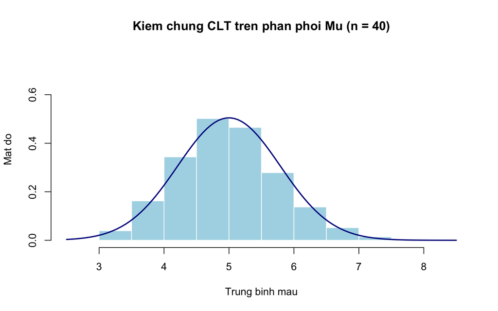

```r
n_clt <- 40
lambda_clt <- 0.2
sim_means <- simulate_clt_exp(n = n_clt, lambda = lambda_clt)

mu_theory <- 1 / lambda_clt
var_theory <- 1 / (n_clt * lambda_clt^2)
sd_theory <- sqrt(var_theory)

hist(sim_means,
  freq = FALSE,
  main = "Kiem chung CLT tren phan phoi Mu (n = 40)",
  xlab = "Trung binh mau",
  ylab = "Mat do",
  col = "lightblue",
  border = "white",
  ylim = c(0, 0.75)
)

curve(dnorm(x, mean = mu_theory, sd = sd_theory),
  add = TRUE,
  col = "darkblue",
  lwd = 2
)
```

Histogram của 5000 trung bình mẫu khớp rất tốt với đường cong chuẩn lý thuyết, xác nhận CLT hoạt động hiệu quả ngay cả trên tổng thể lệch phải mạnh (phân phối Mũ).

## 3. Khoảng tin cậy 95% cho phương sai

Trích xuất một mẫu đơn lẻ gồm 30 quan sát từ phân phối Mũ. Khoảng tin cậy cho $\sigma^2$ dựa trên phân phối $\chi^2$ với $df = n - 1 = 29$:

$$\left[
\frac{(n-1)S^2}{\chi^2_{1-\alpha/2,\; n-1}} \;;\;
\frac{(n-1)S^2}{\chi^2_{\alpha/2,\; n-1}} \right]$$

```r
single_sample <- rexp(30, rate = lambda_clt)
n_sub <- 30
sample_var <- var(single_sample)

alpha_sub <- 0.05
chi_lower <- qchisq(1 - alpha_sub / 2, df = n_sub - 1)
chi_upper <- qchisq(alpha_sub / 2, df = n_sub - 1)

ci_var_lower <- (n_sub - 1) * sample_var / chi_lower
ci_var_upper <- (n_sub - 1) * sample_var / chi_upper

cat("Phuong sai mau S^2:", round(sample_var, 4), "\n")
```

```
## Phuong sai mau S^2: 27.2273
```

```r
cat("KTC 95%: [", round(ci_var_lower, 4), ";",
  round(ci_var_upper, 4), "]\n")
```

```
## KTC 95%: [ 17.2693 ; 49.2047 ]
```

```r
cat("Phuong sai thuc te (1/lambda^2):", 1 / lambda_clt^2)
```

```
## Phuong sai thuc te (1/lambda^2): 25
```

## 4. Nhận xét đồ họa

```r
ci_labels <- c("Lower Bound", "Upper Bound", "Width")
ci_values <- c(ci_var_lower, ci_var_upper,
  ci_var_upper - ci_var_lower)
df_ci_var <- data.frame(Metric = ci_labels, Value = ci_values)
print(df_ci_var)
```

```
##        Metric    Value
## 1 Lower Bound 17.26928
## 2 Upper Bound 49.20466
## 3       Width 31.93539
```

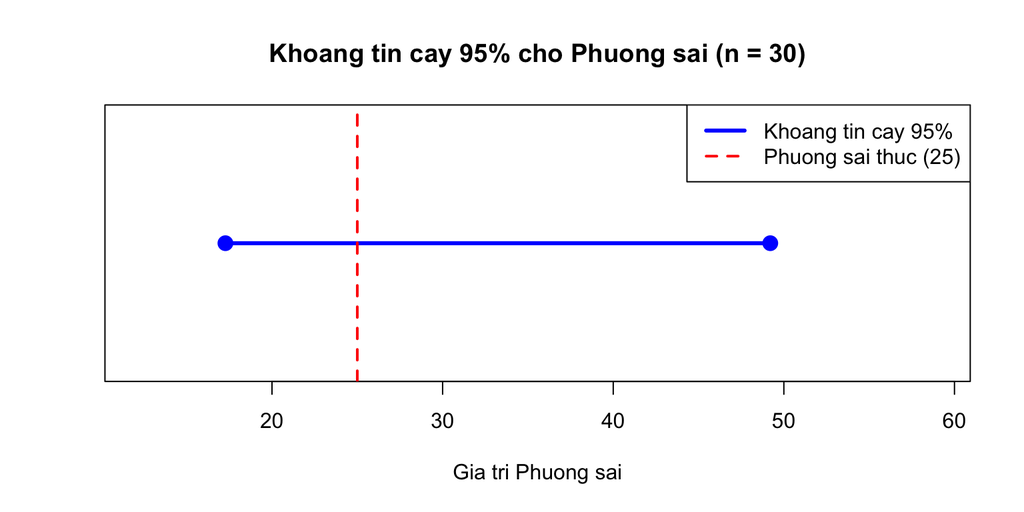

```r
plot(NA,
  xlim = c(ci_var_lower * 0.7, ci_var_upper * 1.2),
  ylim = c(0.5, 1.5),
  xlab = "Gia tri Phuong sai",
  ylab = "",
  yaxt = "n",
  main = "Khoang tin cay 95% cho Phuong sai (n = 30)"
)

lines(c(ci_var_lower, ci_var_upper), c(1, 1),
  col = "blue", lwd = 3)
points(c(ci_var_lower, ci_var_upper), c(1, 1),
  pch = 19, col = "blue", cex = 1.5)

abline(v = 1 / lambda_clt^2, col = "red", lty = 2, lwd = 2)
legend("topright",
  legend = c("Khoang tin cay 95%", "Phuong sai thuc (25)"),
  col = c("blue", "red"),
  lty = c(1, 2),
  lwd = c(3, 2)
)
```

Phương sai tổng thể thực tế $\sigma^2 = 1/\lambda^2 = 25$ nằm trong khoảng tin cậy, cho thấy khoảng ước lượng là hợp lệ.

# Bài tập Nhóm 3 (Capstone): Ước lượng Điểm và Khoảng Toàn diện

## 1. Khởi tạo dữ liệu ẩn

```r
final_data <- data.frame(
  ram_usage = rbeta(3000, shape1 = 2, shape2 = 5)
)
```

## 2. Ước lượng Mô-men (MoM)

Công thức MoM cho phân phối Beta:

$$\hat{\alpha}_{MoM} = \bar{X} \left(
\frac{\bar{X}(1 - \bar{X})}{S^2} - 1 \right), \quad \hat{\beta}_{MoM} =
(1 - \bar{X}) \left( \frac{\bar{X}(1 - \bar{X})}{S^2} - 1
\right)$$

```r
mean_ram <- mean(final_data$ram_usage)
var_ram <- var(final_data$ram_usage)

mom_factor <- (mean_ram * (1 - mean_ram) / var_ram) - 1
alpha_mom <- mean_ram * mom_factor
beta_mom <- (1 - mean_ram) * mom_factor

cat("MoM: alpha =", round(alpha_mom, 4),
  "| beta =", round(beta_mom, 4))
```

```
## MoM: alpha = 1.9717 | beta = 4.8775
```

## 3. Ước lượng Hợp lý Cực đại (MLE)

Hàm mục tiêu Negative Log-Likelihood:

$$\text{NLL}(\alpha, \beta) =
-\sum_{i=1}^{n} \ln f(x_i \mid \alpha, \beta)$$

```r
nll_beta <- function(params, data) {
  a <- params[1]
  b <- params[2]
  -sum(dbeta(data, shape1 = a, shape2 = b, log = TRUE))
}

mle_fit <- nlminb(
  start = c(alpha_mom, beta_mom),
  objective = nll_beta,
  data = final_data$ram_usage,
  lower = c(1e-5, 1e-5)
)

alpha_mle <- mle_fit$par[1]
beta_mle <- mle_fit$par[2]

cat("MLE: alpha =", round(alpha_mle, 4),
  "| beta =", round(beta_mle, 4))
```

```
## MLE: alpha = 1.98 | beta = 4.8972
```

## 4. Trực quan hóa so sánh thuật toán

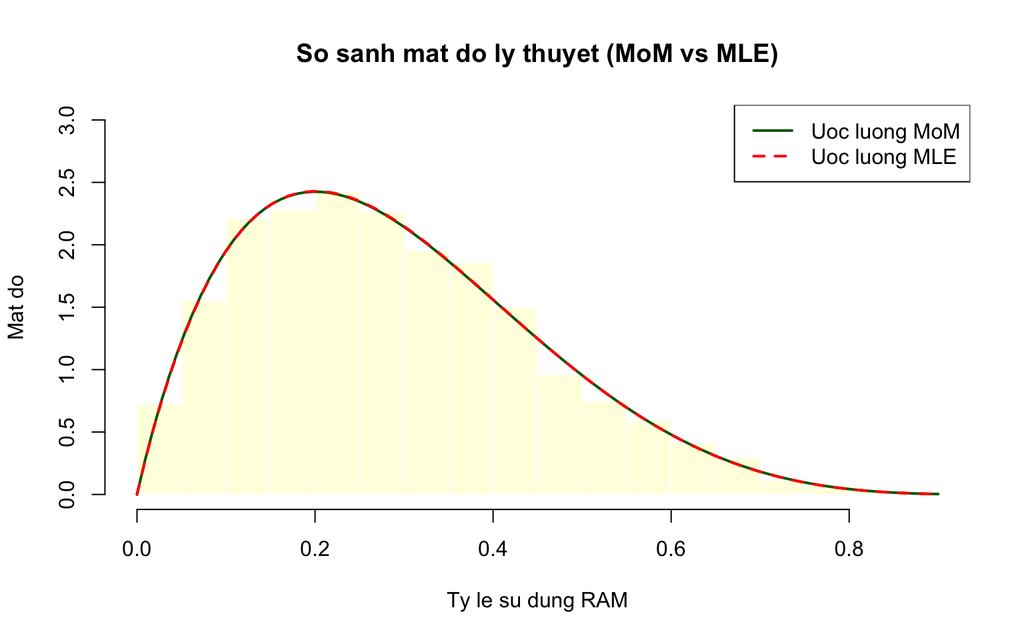

```r
hist(final_data$ram_usage,
  freq = FALSE,
  main = "So sanh mat do ly thuyet (MoM vs MLE)",
  xlab = "Ty le su dung RAM",
  ylab = "Mat do",
  col = "lightyellow",
  border = "white",
  ylim = c(0, 3)
)

curve(dbeta(x, shape1 = alpha_mom, shape2 = beta_mom),
  add = TRUE,
  col = "darkgreen",
  lwd = 2
)

curve(dbeta(x, shape1 = alpha_mle, shape2 = beta_mle),
  add = TRUE,
  col = "red",
  lty = 2,
  lwd = 2
)

legend("topright",
  legend = c("Uoc luong MoM", "Uoc luong MLE"),
  col = c("darkgreen", "red"),
  lty = c(1, 2),
  lwd = c(2, 2)
)
```

Cả hai đường mật độ MoM (nét liền xanh lục) và MLE (nét đứt đỏ) đều khớp rất sát với phân phối thực nghiệm. MLE cho ước lượng tiệm cận chính xác hơn do tận dụng toàn bộ thông tin của mẫu thông qua hàm hợp lý.

## 5. Khoảng tin cậy phi tham số cho Trung vị

Khoảng tin cậy 99% cho trung vị dựa trên thống kê thứ tự. Chỉ số $k$ và $r$ được xác định từ phân phối nhị thức $Binomial(n, 0.5)$:

```r
n_ram <- length(final_data$ram_usage)
alpha_med <- 0.01

k_med <- qbinom(alpha_med / 2, size = n_ram, prob = 0.5)
r_med <- qbinom(1 - alpha_med / 2, size = n_ram, prob = 0.5) + 1

sorted_ram <- sort(final_data$ram_usage)
ci_med_lower <- sorted_ram[k_med]
ci_med_upper <- sorted_ram[r_med]

cat("KTC 99% cho Median: [", round(ci_med_lower, 4), ";",
  round(ci_med_upper, 4), "]\n")
```

```
## KTC 99% cho Median: [ 0.2572 ; 0.2791 ]
```

```r
cat("Trung vi mau thuc te:", round(median(final_data$ram_usage), 4))
```

```
## Trung vi mau thuc te: 0.2696
```

Trung vị mẫu nằm hoàn toàn trong khoảng tin cậy, xác nhận phương pháp thống kê thứ tự hoạt động đúng đắn trên phân phối bất đối xứng.